# Zależność pomiędzy dwiema zmiennymi binarnymi

pogRomcy danych

sezon 2 / odcinek 18  
[Przemysław Biecek @ Uniwersytet Warszawski](http://biecek.pl/)  
Naciśnij `A` by zamienić slajdy na ciągły tekst.  
Naciśnij `T` by wyświetlić spis treści.

# O czym jest ten odcinek

Jak badać czy dwie zmienne są zależne?

Co oznacza zależność?

W tym odcinku rozważymy najprostszą zależność dla pary zmiennych - zależność pomiędzy parą zmiennych binarnych.

W tym odcinku nauczymy się:

- jak budować i jak czytać tablice kontyngencji dla pary zmiennych
- jak przedstawiać graficznie tabelę kontyngencji
- jak statystycznie testować zależność pomiędzy parą zmiennych.

Do ilustracji tych zagadnień wykorzystamy dwa zbiory danych. Pierwszy, to dane z Diagnozy Społecznej, dostępne w tabeli `diagnoza` a drugi o nowotworze piersi, dostępne w tabeli `TCGA_BRCA`. Oba dostępne w pakiecie `PogromcyDanych`.

# Jak opisać zależność dwóch zmiennych binarnych

Zmienne binarne, to zmienne, które przyjmują po dwie wartości.

Zmienne takie można prosto scharakteryzować. Wystarczy napisać ile razy wystąpiła pierwsza wartość, ile razy druga i w ten sposób dwie liczby opisują obserwacje.

Typową zmienną binarną jest płeć ze swoimi dwoma poziomami/wartościami. Zmiennymi binarnymi są też zmienne logiczne przyjmujące wartości TRUE/FALSE.

Zmienne jakościowe przyjmujące więcej poziomów lub zmienne ciągłe można binaryzować i często wykonuje się tę operację. Jeżeli mamy zmienną opisującą kolor włosów i w zbiorze danych jest dziesięć różnych kolorów, ale większość osób to bruneci/brunetki, wtedy na potrzeby analiz wygodnie może być zamienić zmienną z kilkoma poziomami na binarną. Np. odpowiadającą na pytanie: czy to brunet (a więc po połączeniu pozostałych poziomów w jeden ‘nie brunet/ka’). Jeżeli mamy zmienną ciągłą - wzrost, możemy ją zbinaryzować dzieląc wzrost na dwa przedziały, np. do 170 cm i powyżej. Zamiast ciśnienia użyteczna może być informacja czy ciśnienie jest w normie czy jest podwyższone, zamiast wykształcenia informacja czy z maturą czy bez itp.

# Po co binaryzować

W tym miejscu powinno pojawić się pytanie *po co*? Po co redukować więcej informacji do dwóch poziomów?

Główną zaletą jest łatwość opisu. Jedną zmienną binarną opisać można za pomocą dwóch liczb.

Relację pomiędzy dwoma zmiennymi binarnymi opisać można za pomocą czterech liczb. A więc za pomocą tak zwanej tablicy kontyngencji.

| . | Zmienna 1: A | Zmienna 1: B |
| --- | --- | --- |
| Zmienna 2: X | $n_{1,1}$ | $n_{2,1}$ |
| Zmienna 2: Y | $n_{1,2}$ | $n_{2,2}$ |

Zależność pomiędzy dwoma zmiennymi binarnymi opisują cztery liczby, $n_{1,1}$ opisuje liczbę przypadków w których zmienna 1 przyjmuje wartość A a zmienna 2 wartość X, $n_{1,2}$ opisuje liczbę przypadków w których zmienna 1 przyjmuje wartość A a zmienna 2 wartość Y, i tak dalej.

# Wczytanie danych

Zobaczmy jak ten opis wygląda dla danych `diagnoza` z pakietu `PogromcyDanych`. Aby te dane wczytać, wystarczy włączyć pakiet funkcją `library()` (wcześniej trzeba go zainstalować).

W zbiorze danych `diagnoza` dostępnych jest kilkadziesiąt kolumn, opisujących odpowiedzi na różne interesujące pytania. W tym odcinku przyjrzymy się tylko kilku wybranym kolumnom, opisującym imię, wiek, płeć, ukończoną edukację oraz odpowiedź na pytanie ,,Co jest według Pana ważniejsze w życiu?’’ (zmienna w kolumnie `gp29`) z możliwymi odpowiedziami *Poczucie sensu* i *Przyjemności*.

```r
library(PogromcyDanych)
diagnoza[1:6, c("imie_2011", "wiek2013", "plec", "eduk4_2013", "gp29")]
```

```
##   imie_2011 wiek2013      plec                    eduk4_2013
## 1  WERONIKA        4   kobieta                          <NA>
## 2    ERNEST       13 mężczyzna zasadnicze zawodowe/gimanzjum
## 3    SYLWIA       23   kobieta           wyższe i policealne
## 4   MARIOLA       27   kobieta           wyższe i policealne
## 5    WACŁAW       78 mężczyzna           podstawowe i niższe
## 6     PIOTR       48 mężczyzna zasadnicze zawodowe/gimanzjum
##             gp29
## 1           <NA>
## 2 POCZUCIE SENSU
## 3   PRZYJEMNOSCI
## 4 POCZUCIE SENSU
## 5 POCZUCIE SENSU
## 6 POCZUCIE SENSU
```

# Jak wygląda tabela kontyngencji

W zbiorze danych `diagnoza` mamy dwie binarne zmienne, `plec`, czyli płeć respondenta i `gp29`, czyli odpowiedź na pytanie co jest ważniejsze w życiu.

Zobaczmy jak wygląda tablica kontyngencji, zestawiająca te dwie zmienne.

```r
table(diagnoza$plec, diagnoza$gp29)
```

```
##
##             PRZYJEMNOSCI POCZUCIE SENSU
##   mężczyzna         5114           6544
##   kobieta           5144           9421
```

Przyjrzyjmy się tym wynikom

- 5114 mężczyzn odpowiedziało, że ważniejsze są przyjemności,
- 6544 mężczyzn odpowiedziało, że ważniejsze jest poczucie sensu,
- 5144 kobiet odpowiedziało, że ważniejsze są przyjemności,
- 9421 kobiet odpowiedziało, że ważniejsze jest poczucie sensu.

Domyślne zachowanie funkcji `table()` jest taki, że pomija wartości brakujące. Aby je też wyświetlić, należy dodać argument `useNA = "always"`.

```r
table(diagnoza$plec, diagnoza$gp29, useNA = "always")
```

```
##
##             PRZYJEMNOSCI POCZUCIE SENSU <NA>
##   mężczyzna         5114           6544 6697
##   kobieta           5144           9421 5501
##   <NA>                 0              0   40
```

# Jak wygląda tabela z wartościami brzegowymi

Zarówno kobiety jak i mężczyźni częściej deklarują, że ważniejsze jest poczucie sensu. Ale czy są różnice pomiędzy tymi płciami i jak duże?

Funkcją `addmargins()` można dodać sumę wartości w wierszach i kolumnach.

```r
plecSens <- table(diagnoza$plec, diagnoza$gp29)
addmargins(plecSens)
```

```
##
##             PRZYJEMNOSCI POCZUCIE SENSU   Sum
##   mężczyzna         5114           6544 11658
##   kobieta           5144           9421 14565
##   Sum              10258          15965 26223
```

# Jak wygląda tabela z procentami

Przeliczmy liczebności na frakcje. Jaki procent mężczyzn odpowiedziało przyjemności a jaka poczucie sensu?

Funkcją `prop.table()` można policzyć frakcje. Dodatkowy argument określa, czy mają być to proporcje w wierszach (1), kolumnach (2) czy całej macierzy (pusty argument).

```r
plecSens <- table(diagnoza$plec, diagnoza$gp29)
# frakcje w wierszach
prop.table(plecSens, 1)
```

```
##
##             PRZYJEMNOSCI POCZUCIE SENSU
##   mężczyzna    0.4386687      0.5613313
##   kobieta      0.3531754      0.6468246
```

```r
# frakcje w całej tabeli
prop.table(plecSens)
```

```
##
##             PRZYJEMNOSCI POCZUCIE SENSU
##   mężczyzna    0.1950196      0.2495519
##   kobieta      0.1961637      0.3592648
```

# Jak wyglądają szanse

Pracując ze zmiennymi binarnymi, często zamiast prawdopodobieństw korzysta się z tak zwanych szans (ang. odds).

Co to jest szansa?

Szansa wystąpienia zjawiska X to prawdopodobieństwo wystąpienia X podzielone przez prawdopodobieństwo nie wystąpienia X. Czyli jeżeli prawdopodobieństwo oznaczymy symbolem $p$ to otrzymamy

$odds = \frac{p}{1-p}$

W przeciwieństwie do prawdopodobieństwa, szansa może przyjmować wartości większe od 1.

Policzmy szanse, że kobieta lub mężczyzna odpowie *Przyjemności* na pytanie o to co ważniejsze.

```r
frakcje <- prop.table(plecSens, 1)
frakcje[,1]/frakcje[,2]
```

```
## mężczyzna   kobieta
## 0.7814792 0.5460142
```

# Jak wyglądają ilorazy szans

Jaka jest zaleta w używaniu szans nad prawdopodobieństwem?

Główną zaletą jest możliwość operowania na ilorazach szans. Iloraz szans przedstawia ile razy szansa w jednej grupie jest większa od szansy w dużej grupie.

$oddsRatio_{A/B} = odds_{A}/odds_{B} = \frac{p_A}{(1-p_A)} \frac{(1-p_B)}{p_B}$

Przedstawmy iloraz szans na przykładzie płci i odpowiedzi na pytanie o wartości ważne w życiu.

Policzymy ilu krotnie szansa na odpowiedź *Przyjemności* jest większa u mężczyzn, niż u kobiet.

Jeżeli iloraz szans wynosi 1 to znaczy, że szanse w obu grupach są równe. Gdyby szansa na odpowiedź *Przyjemności* była taka sama w obu grupach, to uznalibyśmy, że te dwie zmienne nie są zależne (wyniki jednej nie zależą od drugiej).

Jeżeli szansa jest mniejsza lub większa niż jeden, wtedy pojawia się zależność.

W przykładzie dla Diagnozy Społecznej, iloraz szans wynosi `1.4312`, co oznacza, że szansa, że dla losowo wylosowanego mężczyzny, szansa że odpowie *Przyjemności* jest o 43% większa niż u kobiety.

```r
frakcje <- prop.table(plecSens, 1)
szanse <- frakcje[,1]/frakcje[,2]
szanse[1] / szanse[2]
```

```
## mężczyzna
##  1.431243
```

# Wykres mozaikowy

Tabele kontyngencji zazwyczaj przedstawia się za pomocą wykresu mozaikowego.

W programie R wystarczy w tym celu wykorzystać funkcję `mosaicplot()`.

Szerokość słupków odzwierciedla względne proporcje kobiet i mężczyzn w zbiorze danych. Każda z kolumn jest podzielona na długości słupków proporcjonalne do odpowiedzi na pytanie o to co ważne osobno dla każdej płci.

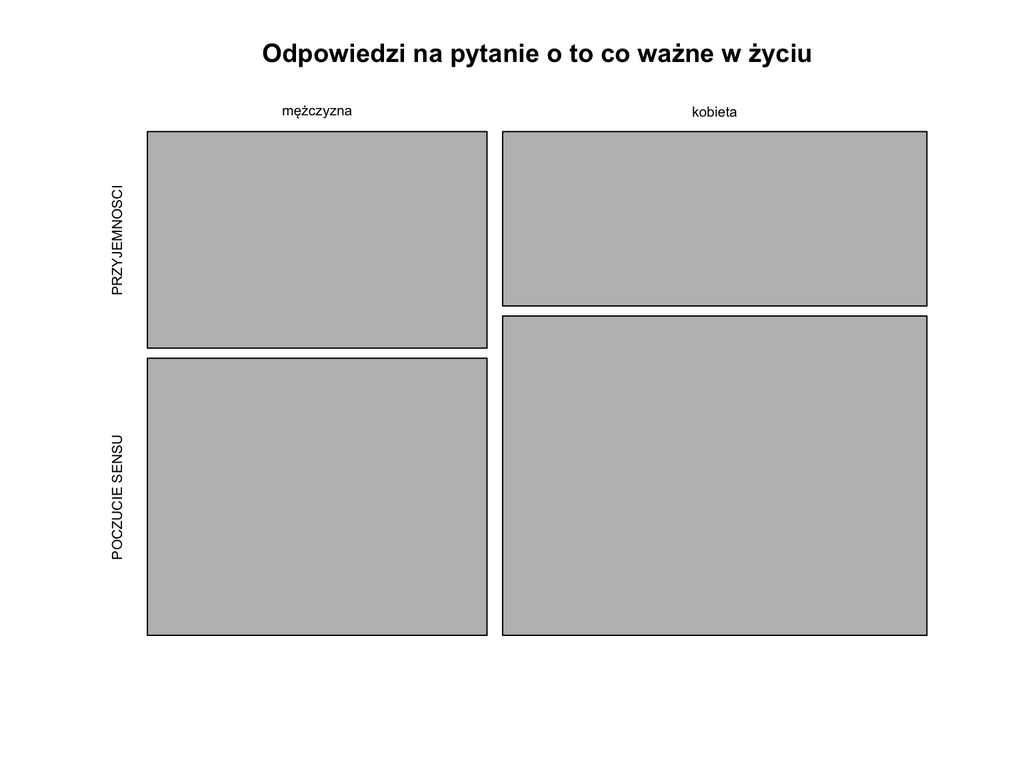

```r
mosaicplot(plecSens, main="Odpowiedzi na pytanie o to co ważne w życiu")
```

# Wczytanie danych

W zbiorze danych `diagnoza` jest ponad 38 tysięcy obserwacji. Dla tak dużej populacji, nawet bardzo małe różnice okazują się istotnie różne.

Dlatego przykład dotyczący testowania przedstawimy na innym zbiorze danych, zbiorze `TCGA_BRCA` z wybranymi zmiennymi dla raka piersi. W tym zbiorze danych mamy wyniki dla 999 pacjentów.

Kolejne kolumny tego zbioru danych opisują takie cechy jak: mutacja genu P53, płeć pacjenta, informację czy pacjent wciąż żyje, informacja ile dni po operacji doszło do zgonu oraz informacja czy w okresie jednego roku pojawił się guz / przerzuty.

```r
head(TCGA_BRCA)
```

```
##                TP53   plec czy.zyje dni.do.smierci czy.nowy.guz
## 1         Wild type female     live             NA           no
## 2             Other female     live             NA         <NA>
## 3         Wild type female     live             NA           no
## 4         Wild type female     live             NA           no
## 5 Missense_Mutation female     dead           1009         <NA>
## 6         Wild type female     live             NA           no
```

# Czy przerzuty pogarszają rokowanie

Zobaczmy czy jest prawdopodobieństwo zgonu (zmienna `czy.zyje`) zależy od występowania przerzutów (zmienna `czy.nowy.guz`).

Zacznijmy od wyznaczenia tablicy kontyngencji.

```r
(przerzuty_przezycia <- table(TCGA_BRCA$czy.nowy.guz,
      TCGA_BRCA$czy.zyje))
```

```
##
##       dead live
##   no    17  342
##   yes   23   20
```

Przedstawmy tę tabelę graficznie

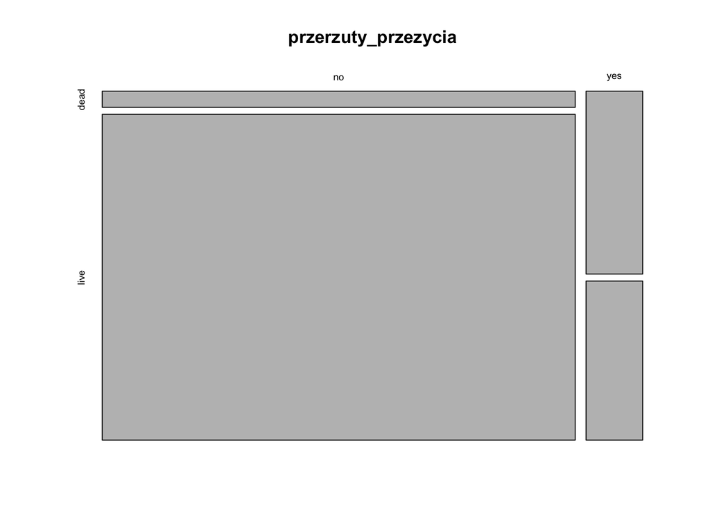

```r
mosaicplot(przerzuty_przezycia)
```

# Czy przerzuty pogarszają rokowanie

Policzmy teraz frakcje osób, które przeżyły i które zmarły osobno w grupie osób bez i z przerzutami.

```r
(frakcje <- prop.table(przerzuty_przezycia, 1))
```

```
##
##             dead       live
##   no  0.04735376 0.95264624
##   yes 0.53488372 0.46511628
```

Policzmy szanse zgonu w grupie osób bez przerzutów i z przerzutami.

```r
(szanse <- frakcje[,1]/frakcje[,2])
```

```
##        no       yes
## 0.0497076 1.1500000
```

```r
# bez przerzutów do przerzutów
szanse[1] / szanse[2]
```

```
##       no
## 0.043224
```

```r
# z przerzutami do bez przerzutów
szanse[2] / szanse[1]
```

```
##      yes
## 23.13529
```

# Czy przerzuty pogarszają rokowanie

Iloraz szans równy 23 wydaje się byś istotnie większy niż 1 (co jak wiemy, oznacza brak zależności).

Aby przetestować czy ta zależność pomiędzy przerzutami a przeżyciem jest istotna statystyczna można przeprowadzić test.

Dla tabel 2 na 2 najbardziej popularnym rozwiązaniem jest użycie testu Fishera. Podobnie jak dla testu dla regresji i testu dla średnich (które omawialiśmy cztery odcinki wcześniej), też test Fishera opiera się na badaniu, jak często przypadkowo iloraz byłby większy niż obserwowany (przy założeniu że tyle samo osób ma przerzuty i tyle samo osób umiera).

Czyli p-wartość wyznaczona w tym teście odpowiada prawdopodobieństwu, że obserwowany iloraz szans jest większy niż obserwowany w sytuacji gdyby pomiędzy zmiennymi nie było żadnych zależności.

```r
fisher.test(przerzuty_przezycia)
```

```
##
##  Fisher's Exact Test for Count Data
##
## data:  przerzuty_przezycia
## p-value = 2.155e-15
## alternative hypothesis: true odds ratio is not equal to 1
## 95 percent confidence interval:
##  0.0186201 0.1006088
## sample estimates:
## odds ratio
##  0.0439938
```

W tym przykładzie p-wartość jest rzędu $2 * 10^{-15}$, tak więc gdyby zmienne nie były zależne, byłoby nieprawdopodobne by zaobserwować tak duży iloraz szans.

# Zadania

1. W zbiorze danych `diagnoza` wiek respondenta jest w zmiennej o nazwie `wiek2013`. Wyznacz zależność pomiędzy wiekiem podzielonym na dwie grupy, poniżej i powyżej 30 roku życia, a odpowiedziami na pytanie o to co w życiu ważne.
2. W zbiorze danych `TCGA_BRCA` w drugiej kolumnie jest płeć pacjenta. Wyznacz zależność pomiędzy zmiennymi `plec` a `czy.zyje`. Przetestuj tą zależność testem Fishera.